# Ejercicios2

Grupo 2

# EJERCICIOS PARTE 2

## 1. Graficar los puntos

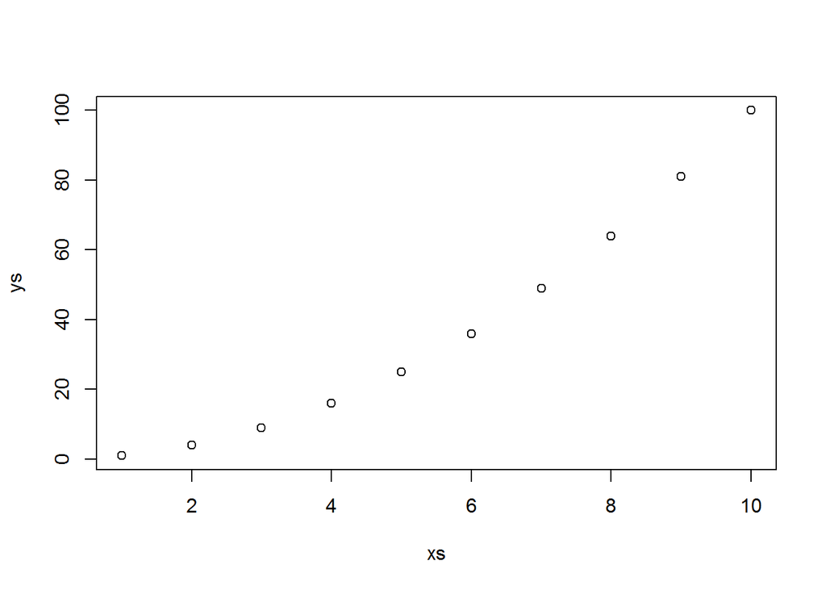

```r
xs<- 1:10
ys<-xs*xs
plot(x = xs, y = ys)
```

## 2. Ingresar la matriz A en RStudio

```r
A<- matrix(1:12, nrow = 4, ncol = 3 )
A
```

```
##      [,1] [,2] [,3]
## [1,]    1    5    9
## [2,]    2    6   10
## [3,]    3    7   11
## [4,]    4    8   12
```

## 3. Ingresar la matriz identidad de tamaño 3

$I = \begin{pmatrix} 1 & 0 & 0 \\ 0 & 1 & 0 \\ 0 & 0 & 1 \end{pmatrix}$

```r
I<- diag(3)
I
```

```
##      [,1] [,2] [,3]
## [1,]    1    0    0
## [2,]    0    1    0
## [3,]    0    0    1
```

## 4. Crea una función que cree una matriz nula ingresando las dimensiones

```r
mat<- function(n){  # "n" sera la dimension
  nula<-diag(n);    #diagional = dimension
  for (i in 1:n) {  #
    nula[i,i]=0;
    return(nula)

  }
}
mat(4)
```

```
##      [,1] [,2] [,3] [,4]
## [1,]    0    0    0    0
## [2,]    0    1    0    0
## [3,]    0    0    1    0
## [4,]    0    0    0    1
```

## 5. Modificar la matriz `diag(4)`, para que se parezca a la matriz B

$B = \begin{pmatrix} 0 & 0 & 0 & 0 \\ 0 & 2 & 0 & 0 \\ 0 & 0 & 3 & 0 \\ 0 & 0 & 0 & 4 \end{pmatrix}$

```r
B<-diag(4)
B[1,1]=0
B[2,2]=2
B[3,3]=3
B[4,4]=4
B
```

```
##      [,1] [,2] [,3] [,4]
## [1,]    0    0    0    0
## [2,]    0    2    0    0
## [3,]    0    0    3    0
## [4,]    0    0    0    4
```

## 6. Obtener la matriz transpuesta de A (ejercicio 2)

```r
A<- matrix(1:12, nrow = 4, ncol = 3 )
t(A)
```

```
##      [,1] [,2] [,3] [,4]
## [1,]    1    2    3    4
## [2,]    5    6    7    8
## [3,]    9   10   11   12
```

## 7. Realizar las siguientes operaciones

$A + B$, $A - B$, $3B$ y $AB$

```r
A<-matrix(c(1:12,rep(0,4)), nrow = 4 , ncol = 4)
B<-matrix(c(0,0,0,0,2,0,0,0,0,3,0,0,0,0,0,4),ncol=4)
(A+B)
```

```
##      [,1] [,2] [,3] [,4]
## [1,]    1    7    9    0
## [2,]    2    6   13    0
## [3,]    3    7   11    0
## [4,]    4    8   12    4
```

```r
(A-B)
```

```
##      [,1] [,2] [,3] [,4]
## [1,]    1    3    9    0
## [2,]    2    6    7    0
## [3,]    3    7   11    0
## [4,]    4    8   12   -4
```

```r
(3*B)
```

```
##      [,1] [,2] [,3] [,4]
## [1,]    0    6    0    0
## [2,]    0    0    9    0
## [3,]    0    0    0    0
## [4,]    0    0    0   12
```

```r
(A*B)
```

```
##      [,1] [,2] [,3] [,4]
## [1,]    0   10    0    0
## [2,]    0    0   30    0
## [3,]    0    0    0    0
## [4,]    0    0    0    0
```

## 8. Crea una función para calcular $P^6$

$P = \begin{pmatrix} 1 & 2 & 3 \\ -2 & 4 & -2 \\ 1 & 0 & 1 \end{pmatrix}$

```r
P<-matrix(c(1,-2,1,2,4,0,3,-2,1),ncol=3)
P
```

```
##      [,1] [,2] [,3]
## [1,]    1    2    3
## [2,]   -2    4   -2
## [3,]    1    0    1
```

```r
PM<-function(M,n){
  S=M;
  for(i in 2:n){
    S=S%*%M};
print(S)}
PM(P,6)
```

```
##       [,1]  [,2]  [,3]
## [1,] -1792    24 -2824
## [2,]  -464 -2416 -1344
## [3,]  -648   440  -912
```

## 9. Resolver el sistema de ecuaciones

$3x - y + z = -1\\9x - 2y + z = -9\\3x + y - 2z = -9$

```r
sol<- matrix(c(3,9,3,-1,-2,1,1,1,-2), nrow = 3,ncol = 3)
x<- c(-1,-9,-9)
solve(sol,x)
```

```
## [1] -1  2  4
```

## 10. Utilizando la ayuda de R, investigue para qué sirven las funciones `eigen()` y `det()`

```r
# Eigen() Los eigenvectors de una matriz son todos aquellos vectores que, al multiplicarlos por dicha matriz, resultan en el mismo vector o en un múltiplo entero del mismo.
# det() es la determinante
```

## 11. Considerando las matrices

$$B=\begin{pmatrix}
1 & 2 & 3 & 4 & 5 \\
2 & 4 & 6 & 8 & 10 \\
3 & 6 & 9 & 12 & 15 \\
4 & 8 & 12 & 16 & 20 \\
5 & 10 & 15 & 20 & 25 \\
6 & 12 & 18 & 24 & 30 \\
7 & 14 & 21 & 28 & 35 \\
8 & 16 & 24 & 32 & 40 \\
9 & 18 & 27 & 36 & 45 \\
10 & 20 & 30 & 40 & 50
\end{pmatrix}$$

$$A = \begin{pmatrix}
0 & 1 & 0 & 1 & 0 \\
1 & 0 & 1 & 0 & 1 \\
0 & 1 & 0 & 1 & 0 \\
0 & 1 & 0 & 0 & 1 \\
1 & 0 & 1 & 1 & 0 \\
\end{pmatrix}$$
Calcular $A \cdot B - A B^t$

```r
B<- matrix(1:50,nrow = 10, ncol = 5)
A<- matrix(c(0,1,0,0,1,1,0,1,1,0,0,1,0,0,1,1,0,1,0,1,0,1,0,1,0),nrow = 5,ncol = 5)
a1<-(B%*%A)
b1<- t(B)
c1<-A%*%b1
#r<-a1 - c1
```

## 12. Considere

$\hat\beta = (X^t \cdot X)^{-1} \cdot X^t \cdot Y$ Determine la matriz $\hat\beta$ $x=\begin{pmatrix}1 & 1\\ 1 & -1\\ 1 & 0\\ 1 & 1\\ 1 & 2\\ \end{pmatrix}$ $y = \begin{pmatrix}0\\0\\1\\1\\3\\\end{pmatrix}$

```r
X<- matrix(c(1,1,1,1,1,1,-1,0,1,2), nrow = 5, ncol = 2)
Y<- matrix(c(0,0,1,1,3), nrow = 5, ncol = 1)
I<- diag(5)
t(X)%*%I%*%Y # %*% MULTIPLICAR matrices
```

```
##      [,1]
## [1,]    5
## [2,]    7
```

## 13. Corre el siguiente código para cargar los vectores `year` y `co2` en memoria

```r
data(co2)
means = aggregate(co2, FUN=mean)
year = as.vector(time(means))
co2 = as.vector(means)
serie<-tibble::tibble(year,co2)
serie
```

[output not shown]

- El vector `co2` contiene medidas de $CO_2$ en la atmósfera, en unidades de *ppm*, durante el periodo 1959-1997. El vector `year` contiene sus años correspondientes.
- Calcular un vector de diferencias de $CO_2$ entre años consecutivos, que sería:
  - $CO_2$ en 1960 menos $CO_2$ en 1959
  - $CO_2$ en 1961 menos $CO_2$ en 1960
  - y así sucesivamente…
- Crear un **plot** con lineas y puntos mostrando las diferencias consecutivas de $CO_2$ en función del tiempo (1960, 1961, etc…), en **negrita**
- La diferencia de concentración de $CO_2$ entre 2020 y 2019 fue igual a 2.64. Agregar un punto rojo representando esa diferencia al plot ya creado (usar una forma diferente, como `pch=4`)

## 14. Lee el archivo `rainfall.csv` como un `data.frame`

- Calcula e imprime un vector con los nombres de las estaciones donde al menos uno de los meses tiene una precipitación superior a 180mm.

```r
data<- read.csv("https://raw.githubusercontent.com/ryali93/ProgramacionR/master/data/rainfall.csv", sep = ",")
#select(c(12,3:11))
tibble(data) %>%
  select(Estaciones = name, Jan = jan, Feb = feb, Mar= mar, Apr = apr, May = may,
         Sep = sep, Oct = oct, Nov = nov, Dec = dec) %>%
  filter(Nov>=180|Dec>=180| Jan>=180)
```

```
## # A tibble: 7 x 10
##   Estaciones   Jan   Feb   Mar   Apr   May   Sep   Oct   Nov   Dec
##   <chr>      <int> <int> <int> <int> <dbl> <dbl> <int> <int> <int>
## 1 Golan Farm   201   196   115    40   9.1   1.9    22    86   159
## 2 Eilon        201   153    92    34   9.5   3.7    36   112   160
## 3 Fasutta      205   179   106    35   7.8   2.6    35   106   162
## 4 Yehiam       204   160    95    32   9.1   2.3    36   115   169
## 5 Kfar Mahol   209   183   105    35   8.3   3.2    30   112   170
## 6 Meron        220   192   109    34   7.6   2.3    28   100   171
## 7 Horashim     238   190   114    38  12.2   3.4    37   122   202
```

```r
#zoo
#zoo rollapply
```